# 001_Matplotlib_sneakers

#### Examining the distribution based on mean and median

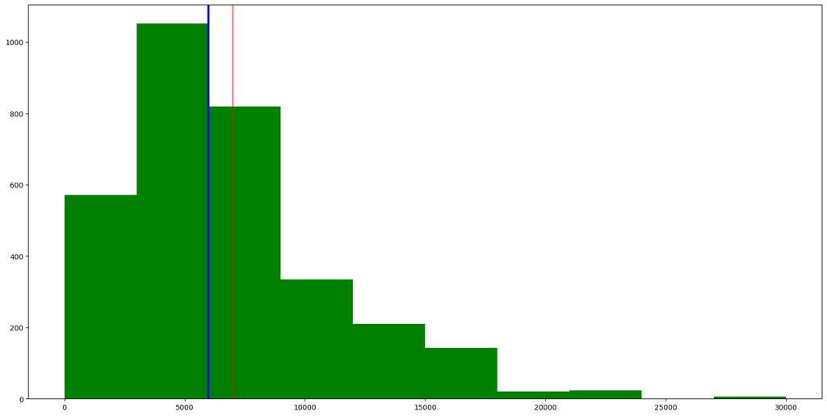

```python
# 1. size of my plot
plt.figure(figsize = (20, 10))

# 2. background color

plt.hist(sneak_pr, color = 'g')

# 3. calculation for the mean ()

plt.axvline (sneak_pr.mean(), color = 'r', linewidth = 1)

# 4. calculation for the median ()

plt.axvline (sneak_pr.median(), color = 'b', linewidth = 3);
```

**Notes:**

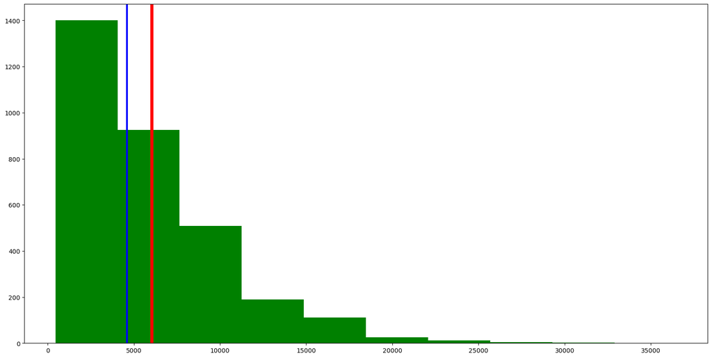

```python
#Univariate analysis for Sale Price variable
sneak_sp = sneakers['Sale Price']

#Examining the distribution based on mean and median
plt.figure(figsize = (20,10))
plt.hist(sneak_sp,color='g')
plt.axvline(sneak_sp.mean(), color='r',linewidth=5)
plt.axvline(sneak_sp.median(),color='b',linewidth=3);
```

Observation:

- Mean Sale Price is around 6000 dollars and Median < 5000 dollars
- Distribution of Sale Price variable is skewed to right

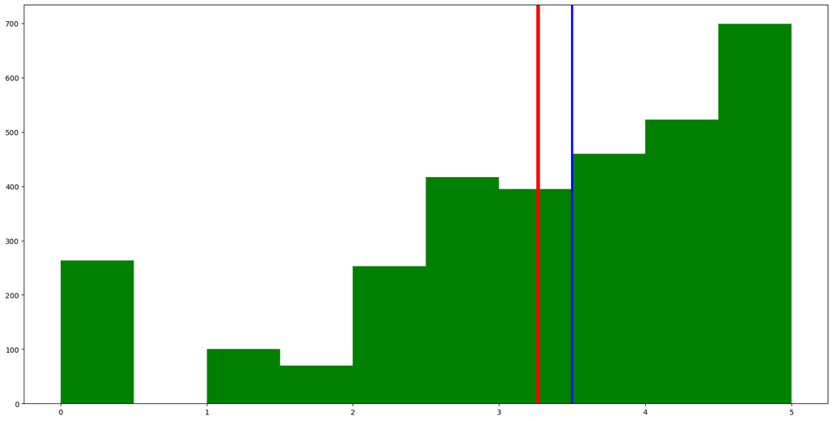

```python
#Univariate analysis for Rating variable
sneak_rating = sneakers['Rating']

#Examining the distribution based on mean and median
plt.figure(figsize = (20,10))
plt.hist(sneak_rating,color='g')
plt.axvline(sneak_rating.mean(), color='r',linewidth=5)
plt.axvline(sneak_rating.median(),color='b',linewidth=3);
```

Observation:

- Mean Rating value is around 3.3 and Median rating is around 3.5
- Distribution of Rating variable is skewed to left

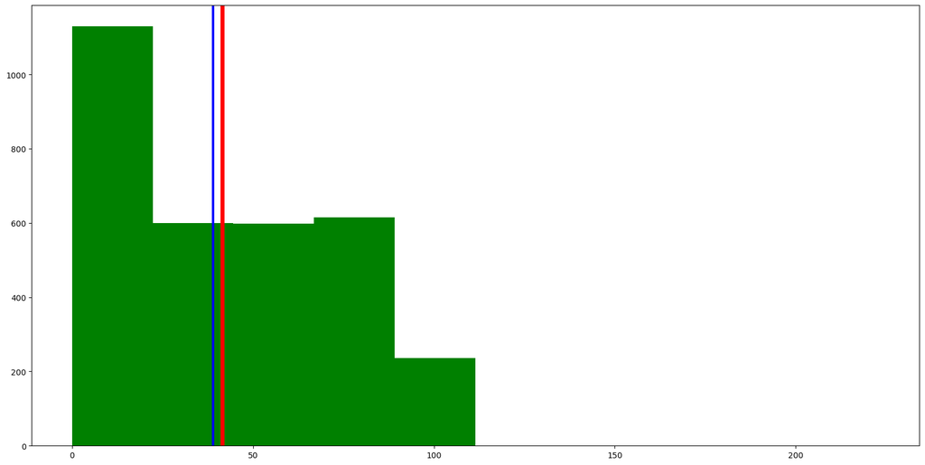

```python
#Univariate analysis for Reviews variable
sneak_reviews = sneakers['Reviews']

#Examining the distribution based on mean and median
plt.figure(figsize = (20,10))
plt.hist(sneak_reviews,color='g')
plt.axvline(sneak_reviews.mean(), color='r',linewidth=5)
plt.axvline(sneak_reviews.median(),color='b',linewidth=3);
```

Observation:

- Mean Reviews count is around 42 and Median rating is around 40
- Distribution of Reviews count variable is slightely skewed to right

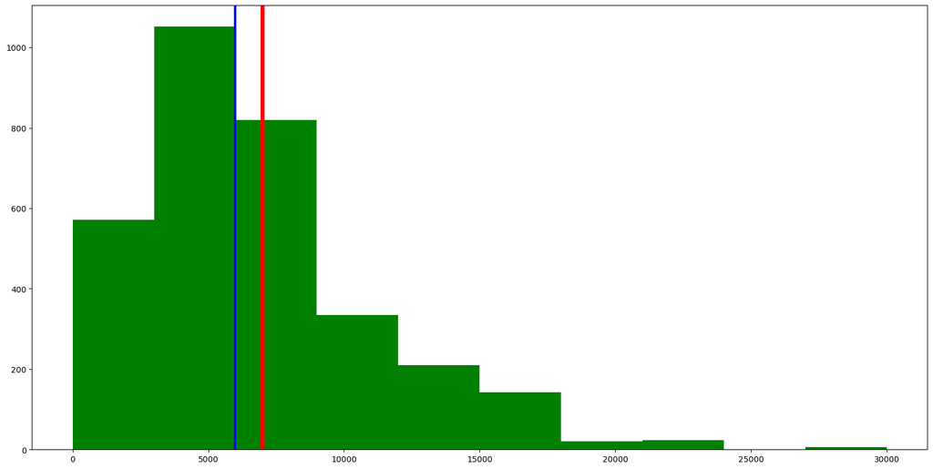

```python
#Univariate analysis for Reviews variable
sneak_reviews = sneakers['Listing Price']

#Examining the distribution based on mean and median
plt.figure(figsize = (20,10))
plt.hist(sneak_reviews,color='g')
plt.axvline(sneak_reviews.mean(), color='r',linewidth=5)
plt.axvline(sneak_reviews.median(),color='b',linewidth=3);
```

Observation:

- Distribution of Listing Price variable is skewed to right.

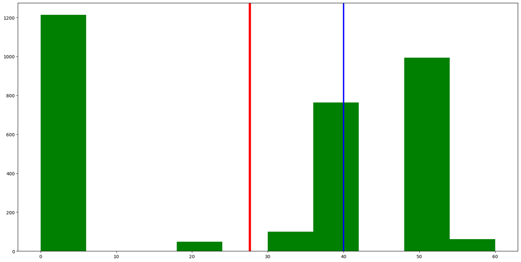

```python
#Univariate analysis for Reviews variable
sneak_reviews = sneakers['Discount']

#Examining the distribution based on mean and median
plt.figure(figsize = (20,10))
plt.hist(sneak_reviews,color='g')
plt.axvline(sneak_reviews.mean(), color='r',linewidth=5)
plt.axvline(sneak_reviews.median(),color='b',linewidth=3);
```

Observation:

- Distribution of Discount variable is skewed to left.